# RSC Bait Development

Jared J. Homola

4/21/2020

## Pt. 1: Selecting samples for building bait panel

This dataset has many samples that failed in library prep or sequencing. We want to use high quality samples for building the bait panel so our selection of loci isn’t biased by large amounts of missing data. To select those samples, we can look at how many SNPs were able to be genotyped in each individual and what the read depth was at the SNPs that were sequenced. Below are histograms for those two factors with the line indicating the cutoff that I used for inclusion in the set of samples used to build the bait panel. This should provide a set of individuals with relatively complete data with relatively high confidence genotype calls.

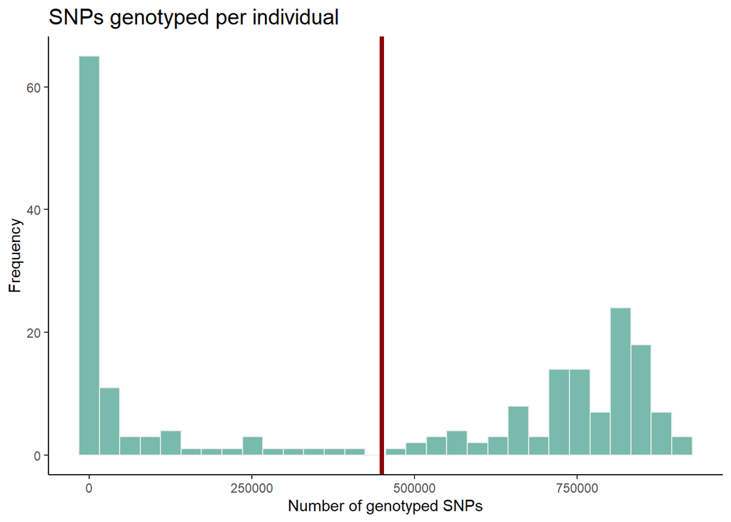

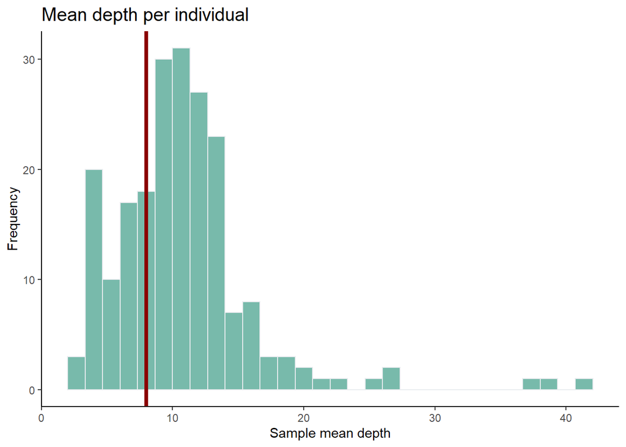

### Sample sizes per population before and after filtering

| popID | siteName | totalN | baitPanelN |
| --- | --- | --- | --- |
| PCALB | Alabama | 13 | 5 |
| PCCAB | Carolina Biological | 22 | 13 |
| PCCHI | Chicago | 21 | 11 |
| PCFCN | Fox Creek North | 16 | 4 |
| PCFCS | Fox Creek South | 11 | 3 |
| PCFMH | Farmington Hills | 17 | 6 |
| PCGDR | Grand Rapids | 15 | 7 |
| PCLOA | Louisiana | 17 | 5 |
| PCMBE | Bioengineering MSU | 10 | 4 |
| PCSHN | East Novi | 10 | 1 |
| PCVKB | Vicksburg | 19 | 3 |
| PCWIS | Wisconsin | 18 | 7 |
| PCWNV | West Novi | 21 | 10 |

## Pt. 2: Selection of loci for bait panel

### Included per-site statistics

1. Missingness: Across all samples
2. MAFs: Across all samples due to low within-pop sample sizes
3. HD plot D scores: Across all samples
4. Allele balance: Across all samples
5. Average read depth: Across all samples
6. Number of SNPs per tag: Across all samples
7. Percentage of heterozygotes: Across all samples

### Distributions and proposed cut-offs

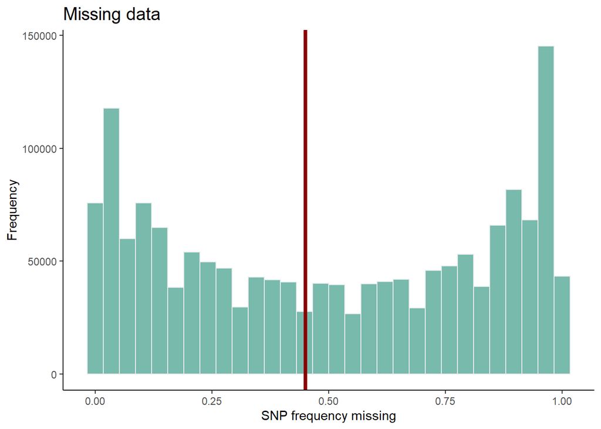

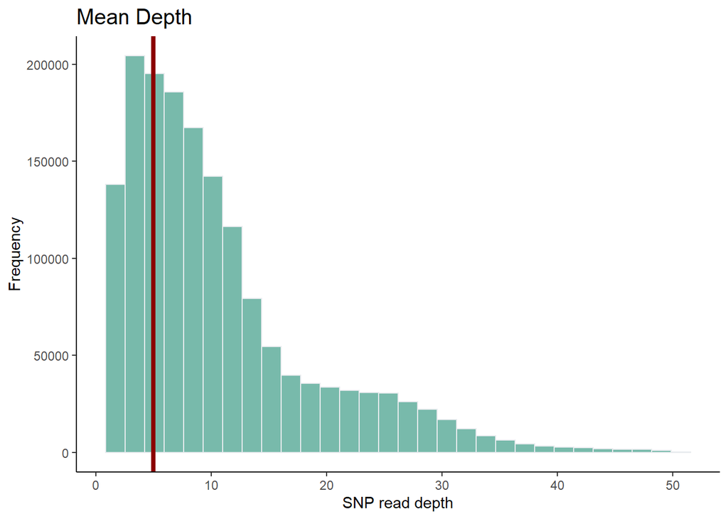

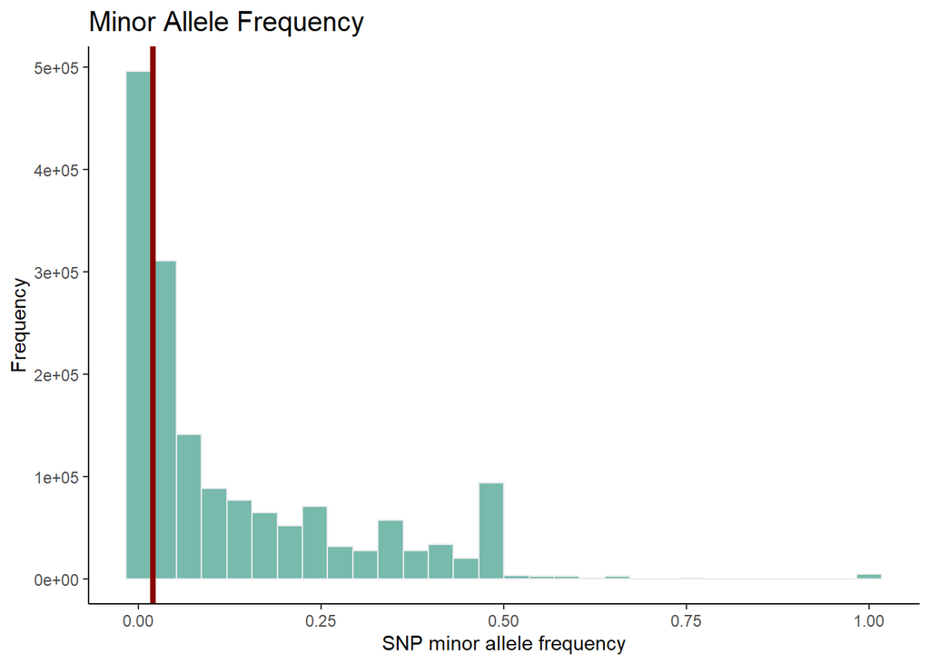

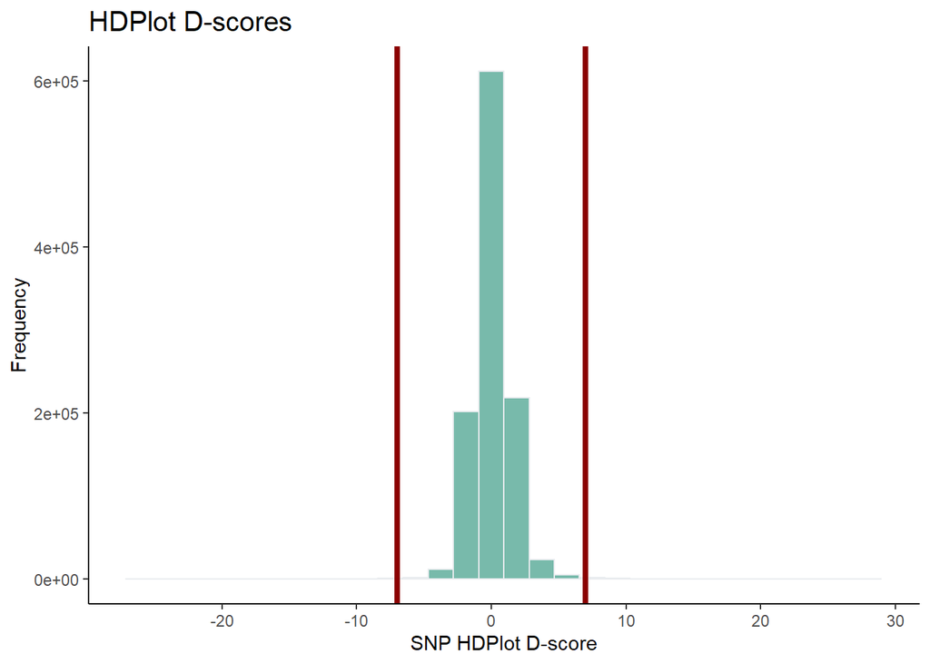

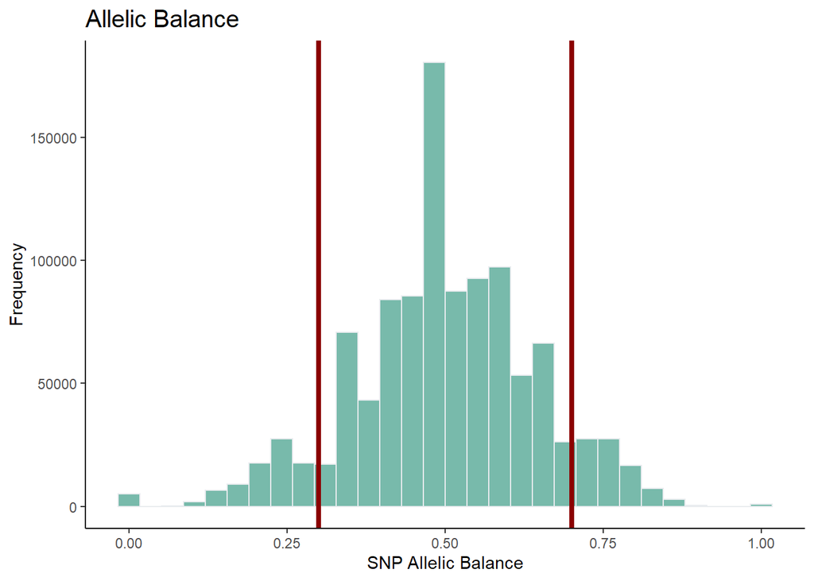

[figure not shown]

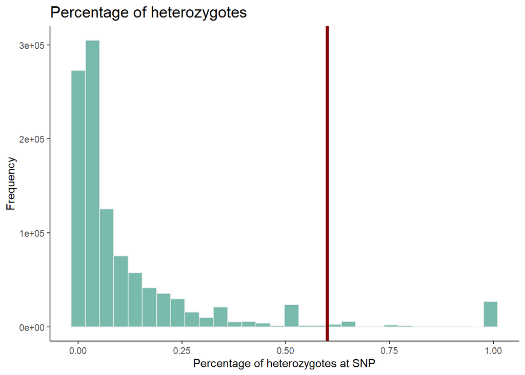

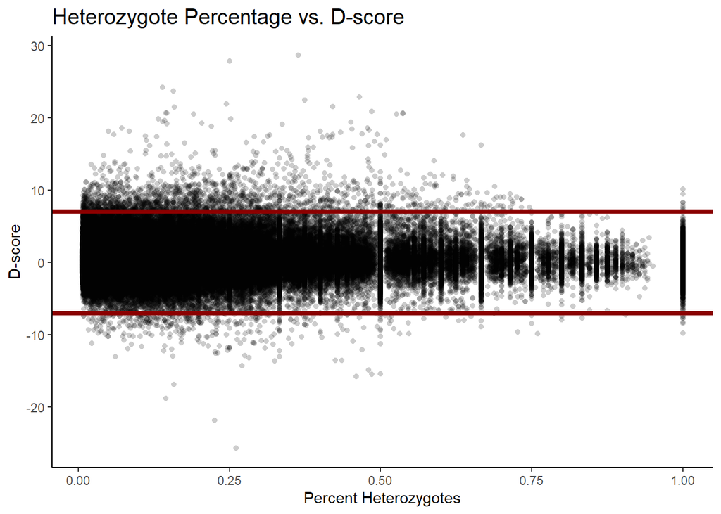

### Filtering scenario

Number provided at the bottom is how many baits we’d have with the filtering thresholds stated in the filtering statements of the following command.

```r
dat %>%
  filter(propMissing < 0.45) %>%
  filter(meanDepth > 5) %>%
  filter(maf > 0.02) %>%
  filter(dScore > -7 | dScore < 7) %>%
  filter(allelicBalance > 0.3 | allelicBalance < 0.7) %>%
  filter(snps < 10) %>%
  filter(hetPerc < 0.6) %>%
  distinct(contig) %>%
  nrow()
```

```
## [1] 2264
```